# *Effects of Climate Events on Health and Economy in the United States over the year of 1950 and 2011*

### Sunah Park, 25. October 2018

## 1. SYNOPSIS

This report identifies the impact of severe weather events on both public health and economy for communities and municipalities in the United States.

For this purpose, historical data about severe weather events in the U.S. from 1950 to November 2011, which are available from the U.S. National Oceanic and Atmospheric Administration’s (NOAA) strom database was used. This database include characteristics of major storms and weather events in the U.S. accompanied with the date and the place of occurrence as well as information about any health damages such as fatalities, injuries and economic damages of properties and crops.

## 2. DATA PROCESSING

The data used for this analysis is available on the following link in the form of a csv(comma-separated-value) file that is compressed via the bzip2 to reduce its size: [Raw Data](https://d396qusza40orc.cloudfront.net/repdata%2Fdata%2FStormData.csv.bz2)

The documentation as well as FAQ of the database can be also found in the following link: [Documentation](https://d396qusza40orc.cloudfront.net/repdata%2Fpeer2_doc%2Fpd01016005curr.pdf) and [FAQ](https://d396qusza40orc.cloudfront.net/repdata%2Fpeer2_doc%2FNCDC%20Storm%20Events-FAQ%20Page.pdf)

### Preparation

```r
knitr::opts_chunk$set(echo = TRUE,cache=TRUE)
rm(list=ls()) # removing all objects
setwd("~/Desktop/Coursera/Data_Science_Specialization/5_Reproducible_Research/W4") # Setting the working directory
library(knitr);library(lattice);library(dplyr)
```

### Loading the data

```r
URL<-"https://d396qusza40orc.cloudfront.net/repdata%2Fdata%2FStormData.csv.bz2"
if(!file.exists("repdata%2Fdata%2FStormData.csv.bz2")) {
        download.file(url=URL, destfile="df_original.csv", method="curl")}

df_orig<-read.csv("df_original.csv", header=TRUE)
summary(df_orig) # Viewing the summary of the data
```

```
##     STATE__                  BGN_DATE             BGN_TIME
##  Min.   : 1.0   5/25/2011 0:00:00:  1202   12:00:00 AM: 10163
##  1st Qu.:19.0   4/27/2011 0:00:00:  1193   06:00:00 PM:  7350
##  Median :30.0   6/9/2011 0:00:00 :  1030   04:00:00 PM:  7261
##  Mean   :31.2   5/30/2004 0:00:00:  1016   05:00:00 PM:  6891
##  3rd Qu.:45.0   4/4/2011 0:00:00 :  1009   12:00:00 PM:  6703
##  Max.   :95.0   4/2/2006 0:00:00 :   981   03:00:00 PM:  6700
##                 (Other)          :895866   (Other)    :857229
##    TIME_ZONE          COUNTY           COUNTYNAME         STATE
##  CST    :547493   Min.   :  0.0   JEFFERSON :  7840   TX     : 83728
##  EST    :245558   1st Qu.: 31.0   WASHINGTON:  7603   KS     : 53440
##  MST    : 68390   Median : 75.0   JACKSON   :  6660   OK     : 46802
##  PST    : 28302   Mean   :100.6   FRANKLIN  :  6256   MO     : 35648
##  AST    :  6360   3rd Qu.:131.0   LINCOLN   :  5937   IA     : 31069
##  HST    :  2563   Max.   :873.0   MADISON   :  5632   NE     : 30271
##  (Other):  3631                   (Other)   :862369   (Other):621339
##                EVTYPE         BGN_RANGE           BGN_AZI
##  HAIL             :288661   Min.   :   0.000          :547332
##  TSTM WIND        :219940   1st Qu.:   0.000   N      : 86752
##  THUNDERSTORM WIND: 82563   Median :   0.000   W      : 38446
##  TORNADO          : 60652   Mean   :   1.484   S      : 37558
##  FLASH FLOOD      : 54277   3rd Qu.:   1.000   E      : 33178
##  FLOOD            : 25326   Max.   :3749.000   NW     : 24041
##  (Other)          :170878                      (Other):134990
##          BGN_LOCATI                  END_DATE             END_TIME
##               :287743                    :243411              :238978
##  COUNTYWIDE   : 19680   4/27/2011 0:00:00:  1214   06:00:00 PM:  9802
##  Countywide   :   993   5/25/2011 0:00:00:  1196   05:00:00 PM:  8314
##  SPRINGFIELD  :   843   6/9/2011 0:00:00 :  1021   04:00:00 PM:  8104
##  SOUTH PORTION:   810   4/4/2011 0:00:00 :  1007   12:00:00 PM:  7483
##  NORTH PORTION:   784   5/30/2004 0:00:00:   998   11:59:00 PM:  7184
##  (Other)      :591444   (Other)          :653450   (Other)    :622432
##    COUNTY_END COUNTYENDN       END_RANGE           END_AZI
##  Min.   :0    Mode:logical   Min.   :  0.0000          :724837
##  1st Qu.:0    NA's:902297    1st Qu.:  0.0000   N      : 28082
##  Median :0                   Median :  0.0000   S      : 22510
##  Mean   :0                   Mean   :  0.9862   W      : 20119
##  3rd Qu.:0                   3rd Qu.:  0.0000   E      : 20047
##  Max.   :0                   Max.   :925.0000   NE     : 14606
##                                                 (Other): 72096
```

[output cut: 41 more lines]

```
##  Min.   :   0   Min.   :-14451   Min.   :   0   Min.   :-14455
##  1st Qu.:2802   1st Qu.:  7247   1st Qu.:   0   1st Qu.:     0
##  Median :3540   Median :  8707   Median :   0   Median :     0
##  Mean   :2875   Mean   :  6940   Mean   :1452   Mean   :  3509
##  3rd Qu.:4019   3rd Qu.:  9605   3rd Qu.:3549   3rd Qu.:  8735
##  Max.   :9706   Max.   : 17124   Max.   :9706   Max.   :106220
##  NA's   :47                      NA's   :40
##                                            REMARKS           REFNUM
##                                                :287433   Min.   :     1
##                                                : 24013   1st Qu.:225575
##  Trees down.\n                                 :  1110   Median :451149
##  Several trees were blown down.\n              :   568   Mean   :451149
##  Trees were downed.\n                          :   446   3rd Qu.:676723
##  Large trees and power lines were blown down.\n:   432   Max.   :902297
##  (Other)                                       :588295
```

### Processing the data

For the analysis, the following seven variables from the original data base are considered: * 1. Type of event (Column name: “EVTYPE”) * 2. Number of Fatalities (Column name: “FATALITIES”) * 3. Number of Injuries (Column name: “INJURIES”) * 4. Property Damage (Column name: “PROPDMG”) * 5. Property Damage Multiplier (Column name: “PROPDMGEXP”) * 6. Crop Damage (Column name: “CROPDMG”) * 7. Crop Damage Multiplier (Column name: “CROPDMGEXP”).

```r
var_new<-c("EVTYPE","FATALITIES","INJURIES","PROPDMG","PROPDMGEXP","CROPDMG","CROPDMGEXP")
df<-df_orig %>% select(var_new)
sum(is.na(df)) # Checking missing values
```

```
## [1] 0
```

```r
head(df,3) # Checking the first 3 rows of the new data frame
```

```
##    EVTYPE FATALITIES INJURIES PROPDMG PROPDMGEXP CROPDMG CROPDMGEXP
## 1 TORNADO          0       15    25.0          K       0
## 2 TORNADO          0        0     2.5          K       0
## 3 TORNADO          0        2    25.0          K       0
```

```r
# Data frame generation for Fatalities and Injuries
df_human<-df %>%
        group_by(EVTYPE) %>%
        summarize(fat=sum(FATALITIES),inj=sum(INJURIES))%>%
        arrange(desc(fat))
# Data frame generation for Property and Crop Damages
df$PROPDMGEXP<-as.character(df$PROPDMGEXP)
df[is.na(df$PROPDMGEXP),"PROPDMGEXP"]<-1
df[grep("k", df$PROPDMGEXP, ignore.case=TRUE), "PROPDMGEXP"]<-10^3;df[grep("K", df$PROPDMGEXP, ignore.case=TRUE), "PROPDMGEXP"]<-10^3
df[grep("m", df$PROPDMGEXP, ignore.case=TRUE), "PROPDMGEXP"]<-10^6;df[grep("M", df$PROPDMGEXP, ignore.case=TRUE), "PROPDMGEXP"]<-10^6
df[grep("B", df$PROPDMGEXP, ignore.case=TRUE), "PROPDMGEXP"]<-10^9
df$PROPDMGEXP<-as.numeric(df$PROPDMGEXP)
sum(is.na(df$PROPDMGEXP))
```

```
## [1] 465955
```

```r
df[is.na(df$PROPDMGEXP),"PROPDMGEXP"]<-1
df$PROPDMG<-df$PROPDMG*df$PROPDMGEXP

df$CROPDMGEXP<-as.character(df$CROPDMGEXP)
df[is.na(df$CROPDMGEXP),"CROPDMGEXP"] <-1
df[grep("k", df$CROPDMGEXP, ignore.case=TRUE), "CROPDMGEXP"]<-10^3;df[grep("K", df$CROPDMGEXP, ignore.case=TRUE), "CROPDMGEXP"]<-10^3
df[grep("m", df$CROPDMGEXP, ignore.case=TRUE), "CROPDMGEXP"]<-10^6;df[grep("M", df$CROPDMGEXP, ignore.case=TRUE), "CROPDMGEXP"]<-10^6
df[grep("B", df$CROPDMGEXP, ignore.case=TRUE), "CROPDMGEXP"]<-10^9
df$CROPDMGEXP<-as.numeric(df$CROPDMGEXP)
sum(is.na(df$CROPDMGEXP))
```

```
## [1] 618420
```

```r
df[is.na(df$CROPDMGEXP),"CROPDMGEXP"]<-1
df$CROPDMG<-df$CROPDMG*df$CROPDMGEXP



df_econ<-df %>%
        select(EVTYPE, PROPDMG,CROPDMG)%>%
        group_by(EVTYPE) %>%
        summarize(prop=sum(PROPDMG)/10^9,
                  crop=sum(CROPDMG)/10^9) %>%
        arrange(desc(prop))
```

Now we have two data frames of (1)df_human: for health damages (fatalities and injuries) and (2)df_econ: for economic damages (property and crop).

## 3. RESULTS

The results are shown in the graphics below.

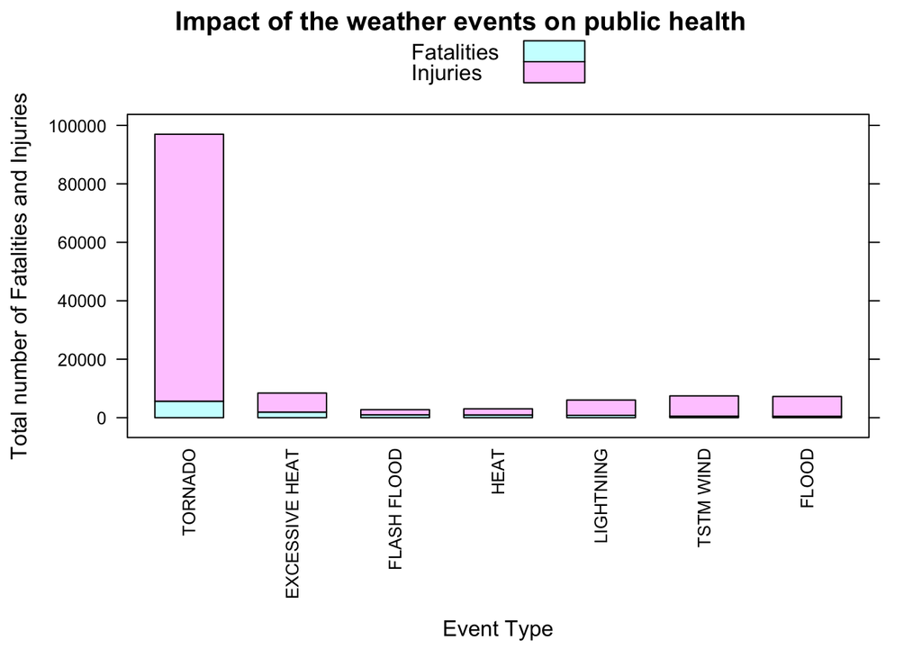

```r
# Visualization of the processed data
# Impact of the weather events on public health (fatalities and injuries):
df_human$EVTYPE<-factor(df_human$EVTYPE,
                levels=unique(as.character(df_human$EVTYPE)))
barchart(fat+inj~EVTYPE, data=df_human[1:7,],stack=TRUE,
         xlab="Event Type",
         ylab="Total number of Fatalities and Injuries",
         main="Impact of the weather events on public health",
         auto.key=list(space="top",text=c("Fatalities","Injuries")),
         scales=list(x=list(rot=90)))
```

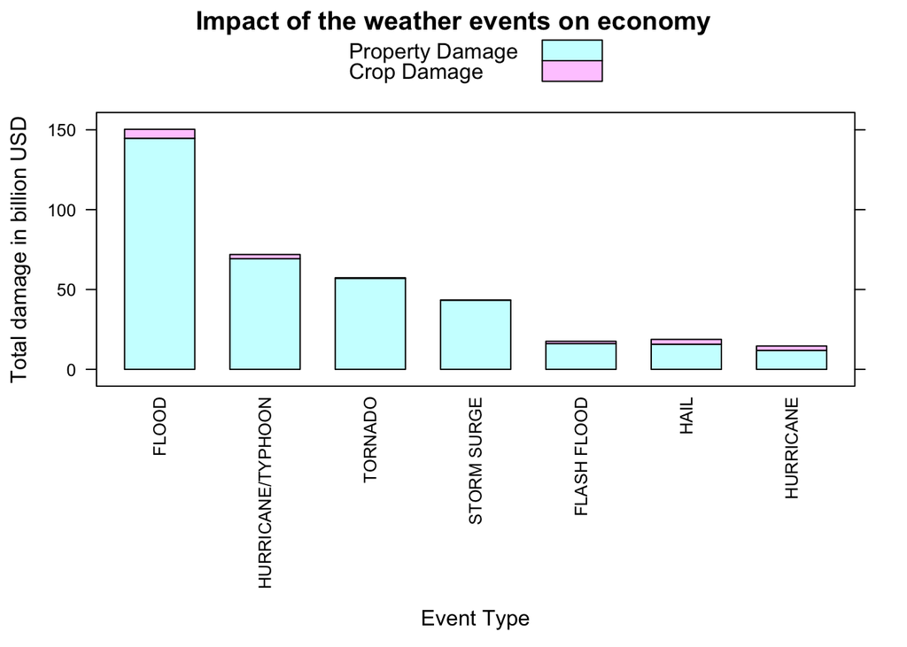

```r
# Impact of the weather events on economy (property and crop damages):
df_econ$EVTYPE<-factor(df_econ$EVTYPE,
                        levels=unique(as.character(df_econ$EVTYPE)))

barchart(prop+crop~EVTYPE, data=df_econ[1:7,],stack=TRUE,
         xlab="Event Type",
         ylab="Total damage in billion USD",
         main="Impact of the weather events on economy",
         auto.key=list(space="top",text=c("Property Damage","Crop Damage")),
         scales=list(x=list(rot=90)))
```

## 4. CONCLUSION

During the period of 1950 and 2011 in the U.S., *‘Tornado’* caused the most impact on both in terms of ‘Fatalities’ and ‘Injuries’. With respect to economic damage, *‘Flood’* was the event that had the largest impact.